# Homework #2

Yi Hang Khor; bobbykhor

## R commands

1. Today’s temperature has a high of 24 and a low of 15 degree fahrenheit. Find the corresponding degress in celsius and storage it in a (single) vector named `cel`. Print the variable.

```r
cel <- (1:2)
cel[1] = (24-32)*5/9
cel[2] = (15-32)*5/9
print(cel)
```

```
## [1] -4.444444 -9.444444
```

2. Create a vector of length 200. The odd entries should be 3 and even entries should be 1. Storage the created in a variable named `vec200` and print.

```r
vec200<-(1:200)
for(i in 1:200){
  if (i%%2!=0){
    vec200[i]=3;
    }
  else{
  vec200[i]=1;
  }
}
print(vec200)
```

```
##   [1] 3 1 3 1 3 1 3 1 3 1 3 1 3 1 3 1 3 1 3 1 3 1 3 1 3 1 3 1 3 1 3 1 3 1 3 1 3
##  [38] 1 3 1 3 1 3 1 3 1 3 1 3 1 3 1 3 1 3 1 3 1 3 1 3 1 3 1 3 1 3 1 3 1 3 1 3 1
##  [75] 3 1 3 1 3 1 3 1 3 1 3 1 3 1 3 1 3 1 3 1 3 1 3 1 3 1 3 1 3 1 3 1 3 1 3 1 3
## [112] 1 3 1 3 1 3 1 3 1 3 1 3 1 3 1 3 1 3 1 3 1 3 1 3 1 3 1 3 1 3 1 3 1 3 1 3 1
## [149] 3 1 3 1 3 1 3 1 3 1 3 1 3 1 3 1 3 1 3 1 3 1 3 1 3 1 3 1 3 1 3 1 3 1 3 1 3
## [186] 1 3 1 3 1 3 1 3 1 3 1 3 1 3 1
```

3. How many perfect squares are there between 1 and 2001? Storage the answer in a variable named `numPerfect` and print. You may want to look at `?round`.

```r
 numPerfect <- 0;
  for(i in 1:2001){
    for(j in 1:i){
      if(j*j ==i){
        numPerfect <- numPerfect+1;
      }
    }
  }
  print(numPerfect)
```

```
## [1] 44
```

## Cars and mileage

For this part we will use the `mpg` data set, you can access the data by first installing (using `install.packages('ggplot2')`) and then loading the package `ggplot2` (using `library(ggplot2)`) into your R session. The `mpg` data includes information about fuel economy of popular car models for the years 1999 and 2008 as collected by the US Environmental Protection Agency. An answer should include a short paragraph of text for the explanation to a (human) reader, together with appropriate R code, outputs, and graphs.

```r
library(ggplot2)
```

1. What are the 3 most fuel-efficient models in terms of highway mileage? Storage the data frame (with 3 rows) containing all information of these three cars in a variable named `top3` and print.

```r
fuel <-mpg[order(mpg$hwy,decreasing=TRUE),]
top3 <- fuel[1:3,]
print(top3)
```

```
## # A tibble: 3 x 11
##   manufacturer model   displ  year   cyl trans   drv     cty   hwy fl    class
##   <chr>        <chr>   <dbl> <int> <int> <chr>   <chr> <int> <int> <chr> <chr>
## 1 volkswagen   jetta     1.9  1999     4 manual~ f        33    44 d     compact
## 2 volkswagen   new be~   1.9  1999     4 manual~ f        35    44 d     subcom~
## 3 volkswagen   new be~   1.9  1999     4 auto(l~ f        29    41 d     subcom~
```

2. How many different compact models are included in this dataset? Storage the answer in a variable named `numCompact` and print.

```r
models <-subset(mpg, mpg$class == 'compact')
numCompact=nrow(models)
print(numCompact)
```

```
## [1] 47
```

3. Create a scatterplot of `hwy` and `cty` and describe the relationship. Why are there so few points visible? Explain your findings.

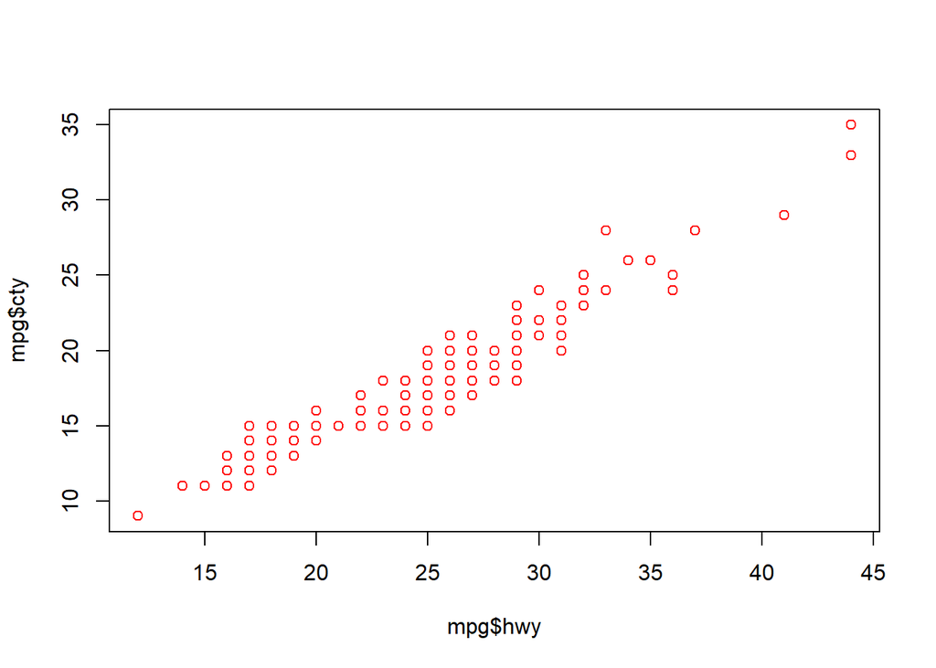

```r
plot(mpg$hwy,mpg$cty,col = 'red')
```

**ANS: The higher the ‘hwy’, the higher the ‘cty’. There are so few points visible due to the repeating of the same points.**

4. Are cars in 2008 more fuel efficient than cars in 1999? Use graphs *and* summary statistics to answer this question. Explain your findings.

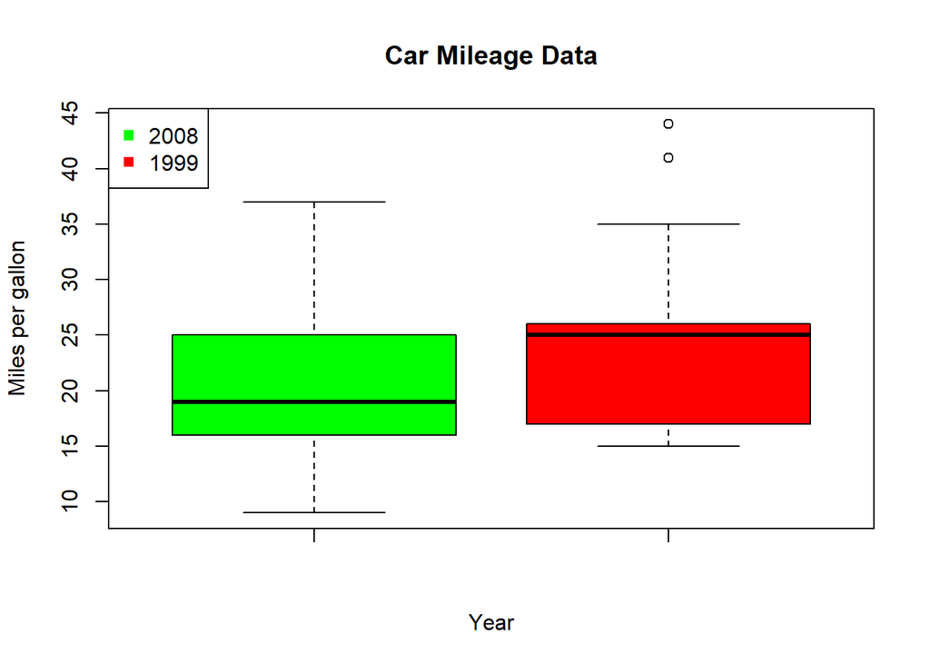

```r
c2008 <- mpg[mpg$year == 2008,]
c1999 <- mpg[mpg$year == 1999,]
boxplot(c(c2008$hwy, c2008$cty),c(c1999$hwy,c1999$hwy),main ="Car Mileage Data",xlab = "Year", ylab = "Miles per gallon",col = c("green","red"))
legend("topleft",legend = c("2008","1999"),col = c("green","red"),pch= 15)
```